# MANOVA TASK

Nzambuli Daniel

2024-02-09

# QUESTIONS:

## Twenty-six samples of Romano-British pottery were found at four different kiln sites in Wales, Gwent and the New Forest. The sites are Llanederyn (L), Caldicot (C), Island Thorns (I), and Ashley Rails (A). The other variables are the percentage of oxides of various metals measured by atomic absorption spectrophotometry. The data were collected to see if different sites contained pottery of different chemical compositions. Each pottery sample was returned to the laboratory for chemical assay. In these assays the concentrations of five different chemicals were determined:

**Variable Names:**

1. **Al:** Percentage of aluminum oxide in sample
2. **Fe:** Percentage of iron oxide in sample
3. **Mg:** Percentage of magnesium oxide in sample
4. **Ca:** Percentage of calcium oxide in sample
5. **Na:** Percentage of sodium oxide in sample
6. **Site:** Site where pottery sample was collected

```r
library(openxlsx)

data = read.csv("MANOVA Task_pottery.csv")
head(data)
```

```
##   Site   Al   Fe   Mg   Ca   Na
## 1    L 14.4 7.00 4.30 0.15 0.51
## 2    L 13.8 7.08 3.43 0.12 0.17
## 3    L 14.6 7.09 3.88 0.13 0.20
## 4    L 11.5 6.37 5.64 0.16 0.14
## 5    L 13.8 7.06 5.34 0.20 0.20
## 6    L 10.9 6.26 3.47 0.17 0.22
```

> - Llanederyn (L)
> - Caldicot (C)
> - Island Thorns (I),
> - Ashley Rails (A)

Use MANOVA to determine whether the chemical content of the pottery depends on the site where the pottery was obtained.

```r
colnames(data)
```

```
## [1] "Site" "Al"   "Fe"   "Mg"   "Ca"   "Na"
```

```r
manov_model = manova(cbind(Al, Fe, Mg, Ca, Na)~Site, data = data )
summary(manov_model)
```

```
##           Df Pillai approx F num Df den Df    Pr(>F)
## Site       3 1.5539   4.2984     15     60 2.413e-05 ***
## Residuals 22
## ---
## Signif. codes:  0 '***' 0.001 '**' 0.01 '*' 0.05 '.' 0.1 ' ' 1
```

There is an F-statistic of `4.2984` and a p-value of `2.413e-5` which is small. This indicates that **there is a statistically significant difference** in the minerals based on the location they were found.

Finding out how the minerals change based on location

```r
summary.aov(manov_model)
```

```
##  Response Al :
##             Df  Sum Sq Mean Sq F value    Pr(>F)
## Site         3 175.610  58.537  26.669 1.627e-07 ***
## Residuals   22  48.288   2.195
## ---
## Signif. codes:  0 '***' 0.001 '**' 0.01 '*' 0.05 '.' 0.1 ' ' 1
##
##  Response Fe :
##             Df  Sum Sq Mean Sq F value    Pr(>F)
## Site         3 134.222  44.741  89.883 1.679e-12 ***
## Residuals   22  10.951   0.498
## ---
## Signif. codes:  0 '***' 0.001 '**' 0.01 '*' 0.05 '.' 0.1 ' ' 1
##
##  Response Mg :
##             Df Sum Sq Mean Sq F value    Pr(>F)
## Site         3 103.35  34.450   49.12 6.452e-10 ***
## Residuals   22  15.43   0.701
## ---
## Signif. codes:  0 '***' 0.001 '**' 0.01 '*' 0.05 '.' 0.1 ' ' 1
##
##  Response Ca :
##             Df   Sum Sq  Mean Sq F value    Pr(>F)
## Site         3 0.204703 0.068234  29.157 7.546e-08 ***
## Residuals   22 0.051486 0.002340
## ---
## Signif. codes:  0 '***' 0.001 '**' 0.01 '*' 0.05 '.' 0.1 ' ' 1
##
##  Response Na :
##             Df  Sum Sq  Mean Sq F value    Pr(>F)
## Site         3 0.25825 0.086082  9.5026 0.0003209 ***
## Residuals   22 0.19929 0.009059
## ---
## Signif. codes:  0 '***' 0.001 '**' 0.01 '*' 0.05 '.' 0.1 ' ' 1
```

```r
effect_on_mineral = data.frame(minerals = c("Al", "Fe", "Mg", "Ca", "Na"),
                               P.val = c(1.627e-07, 1.679e-12, 6.452e-10, 7.546e-08, 0.0003209))
effect_on_mineral = effect_on_mineral[order(effect_on_mineral$P.val),]
effect_on_mineral
```

```
##   minerals     P.val
## 2       Fe 1.679e-12
## 3       Mg 6.452e-10
## 4       Ca 7.546e-08
## 1       Al 1.627e-07
## 5       Na 3.209e-04
```

> From this output the p-values are small -less than `0.05` - with the effect being mostly felt in descending order:
> - Iron
> - Magnesium
> - Calcium
> - Aluminium
> - Sodium

### 1. Which chemical elements vary significantly across sites?

```r
library(gplots)
plot_difference = function(column){
  print(paste("The mean difference of ", column))
  return(plotmeans(data[[column]]~data$Site, xlab = "Site", ylab = column))
}
```

```r
predict_vars = colnames(data)[2:ncol(data)]
predict_vars
```

```
## [1] "Al" "Fe" "Mg" "Ca" "Na"
```

```
## [1] "The mean difference of  Al"
```

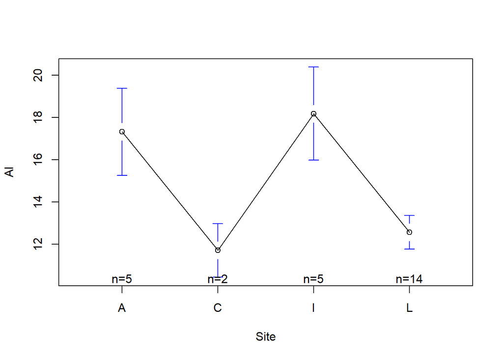

```
## [1] "The mean difference of  Fe"
```

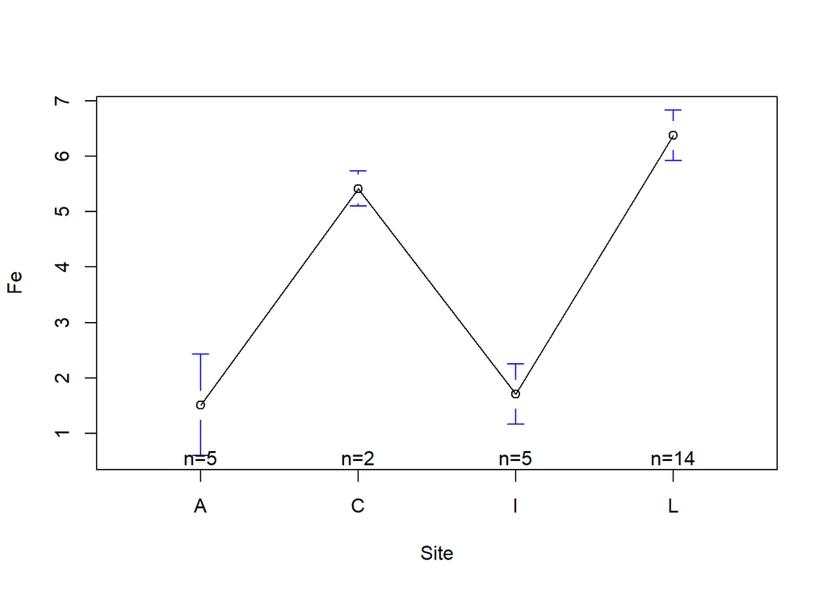

```
## [1] "The mean difference of  Mg"
```

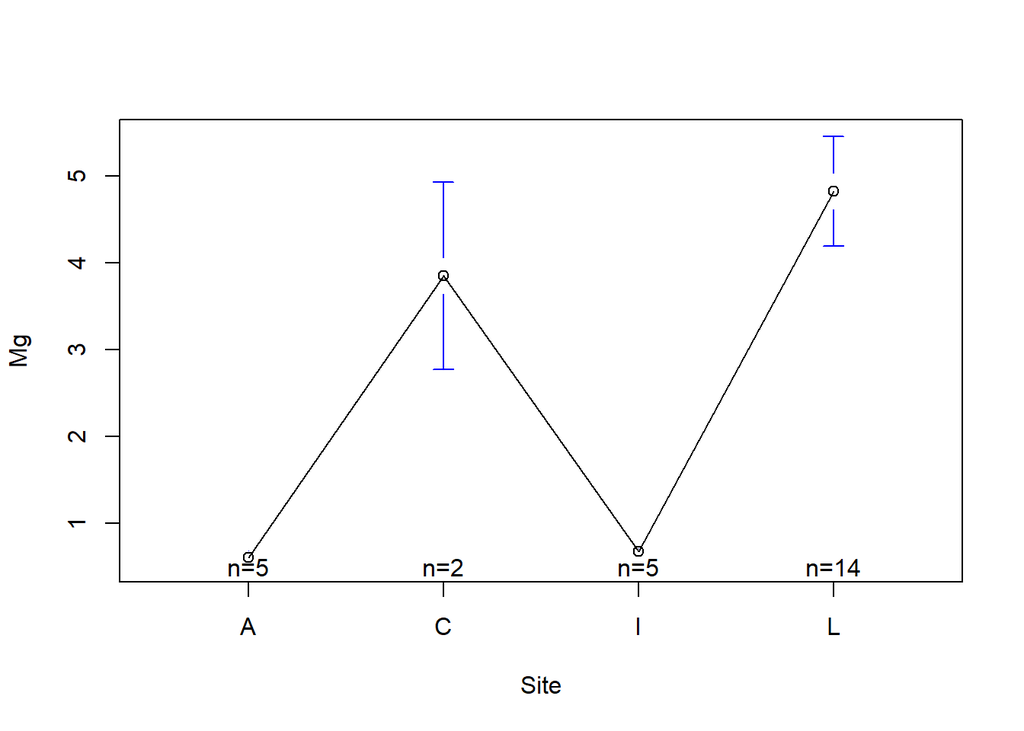

```
## [1] "The mean difference of  Ca"
```

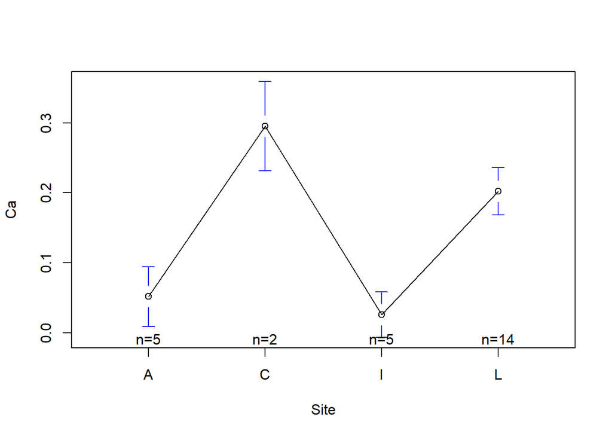

```
## [1] "The mean difference of  Na"
```

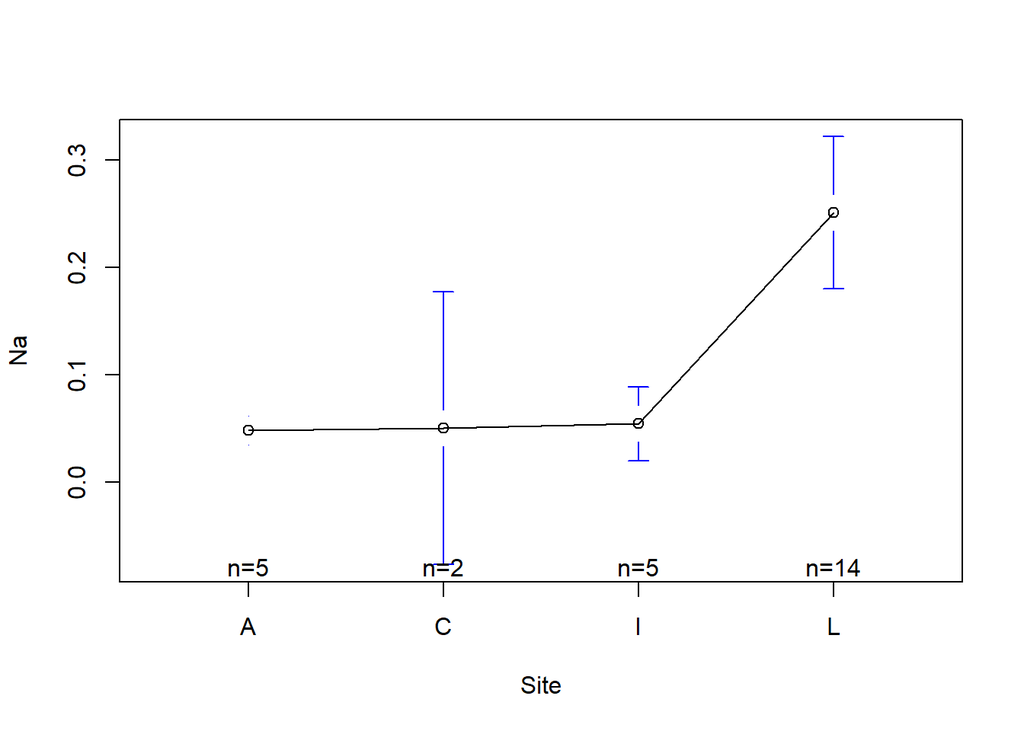

```r
for (i in 1:length(predict_vars)){
  plot_difference(predict_vars[i])
}
```

> **From the plot of means by site**
> - Aluminium, iron, magnesium and calcium keep varying within the locations
> - However in `Island Thorns (I) and Ashley Rails (A)`, the mineral compositions tend to be almost similar. This is also the case for the distribution in `Llanederyn (L) and Caldicot (C)`
> - There is no statistically significant difference in the quantity of `Sodium` in `Island Thorns (I), Caldicot (C) and Ashley Rails (A)` with a large variation when one moves to `Llanederyn (L)`

### 2. How do the sites differ?

**Re-code data by location**

1. llanederyn

```r
library(dplyr)
llanederyn = data %>% mutate(Site = case_when(Site == "L" ~ 1,
                                       TRUE~ 0))
head(llanederyn)
```

```
##   Site   Al   Fe   Mg   Ca   Na
## 1    1 14.4 7.00 4.30 0.15 0.51
## 2    1 13.8 7.08 3.43 0.12 0.17
## 3    1 14.6 7.09 3.88 0.13 0.20
## 4    1 11.5 6.37 5.64 0.16 0.14
## 5    1 13.8 7.06 5.34 0.20 0.20
## 6    1 10.9 6.26 3.47 0.17 0.22
```

```r
print("For llanederyn")
```

```
## [1] "For llanederyn"
```

```r
summary.aov(manova(cbind(Al, Fe, Mg, Ca, Na)~Site, data = llanederyn))
```

```
##  Response Al :
##             Df Sum Sq Mean Sq F value    Pr(>F)
## Site         1 112.76 112.757  24.349 4.908e-05 ***
## Residuals   24 111.14   4.631
## ---
## Signif. codes:  0 '***' 0.001 '**' 0.01 '*' 0.05 '.' 0.1 ' ' 1
##
##  Response Fe :
##             Df  Sum Sq Mean Sq F value    Pr(>F)
## Site         1 110.017 110.017  75.106 7.441e-09 ***
## Residuals   24  35.156   1.465
## ---
## Signif. codes:  0 '***' 0.001 '**' 0.01 '*' 0.05 '.' 0.1 ' ' 1
##
##  Response Mg :
##             Df Sum Sq Mean Sq F value    Pr(>F)
## Site         1 86.112  86.112  63.263 3.496e-08 ***
## Residuals   24 32.668   1.361
## ---
## Signif. codes:  0 '***' 0.001 '**' 0.01 '*' 0.05 '.' 0.1 ' ' 1
##
##  Response Ca :
##             Df   Sum Sq  Mean Sq F value   Pr(>F)
## Site         1 0.093786 0.093786   13.86 0.001058 **
## Residuals   24 0.162402 0.006767
## ---
## Signif. codes:  0 '***' 0.001 '**' 0.01 '*' 0.05 '.' 0.1 ' ' 1
##
##  Response Na :
##             Df  Sum Sq  Mean Sq F value    Pr(>F)
## Site         1 0.25815 0.258154  31.074 9.787e-06 ***
## Residuals   24 0.19939 0.008308
## ---
## Signif. codes:  0 '***' 0.001 '**' 0.01 '*' 0.05 '.' 0.1 ' ' 1
```

2. Caldicot

```r
caldicot = data %>% mutate(Site = case_when(Site == "C" ~ 1,
                                       TRUE~ 0))
head(caldicot)
```

```
##   Site   Al   Fe   Mg   Ca   Na
## 1    0 14.4 7.00 4.30 0.15 0.51
## 2    0 13.8 7.08 3.43 0.12 0.17
## 3    0 14.6 7.09 3.88 0.13 0.20
## 4    0 11.5 6.37 5.64 0.16 0.14
## 5    0 13.8 7.06 5.34 0.20 0.20
## 6    0 10.9 6.26 3.47 0.17 0.22
```

```r
print("For caldicot")
```

```
## [1] "For caldicot"
```

```r
summary.aov(manova(cbind(Al, Fe, Mg, Ca, Na)~Site, data = caldicot))
```

```
##  Response Al :
##             Df  Sum Sq Mean Sq F value Pr(>F)
## Site         1  16.893 16.8935  1.9586 0.1745
## Residuals   24 207.005  8.6252
##
##  Response Fe :
##             Df  Sum Sq Mean Sq F value Pr(>F)
## Site         1   1.944  1.9443  0.3258 0.5734
## Residuals   24 143.228  5.9678
##
##  Response Mg :
##             Df  Sum Sq Mean Sq F value Pr(>F)
## Site         1   1.103  1.1029  0.2249 0.6396
## Residuals   24 117.677  4.9032
##
##  Response Ca :
##             Df   Sum Sq  Mean Sq F value  Pr(>F)
## Site         1 0.047755 0.047755  5.4988 0.02763 *
## Residuals   24 0.208433 0.008685
## ---
## Signif. codes:  0 '***' 0.001 '**' 0.01 '*' 0.05 '.' 0.1 ' ' 1
##
##  Response Na :
##             Df  Sum Sq  Mean Sq F value Pr(>F)
## Site         1 0.02549 0.025489  1.4159 0.2457
## Residuals   24 0.43205 0.018002
```

3. Ashley Rails

```r
Ashley = data %>% mutate(Site = case_when(Site == "A" ~ 1,
                                       TRUE~ 0))
head(Ashley)
```

```
##   Site   Al   Fe   Mg   Ca   Na
## 1    0 14.4 7.00 4.30 0.15 0.51
## 2    0 13.8 7.08 3.43 0.12 0.17
## 3    0 14.6 7.09 3.88 0.13 0.20
## 4    0 11.5 6.37 5.64 0.16 0.14
## 5    0 13.8 7.06 5.34 0.20 0.20
## 6    0 10.9 6.26 3.47 0.17 0.22
```

```r
#difference
print("For Ashley Rails")
```

```
## [1] "For Ashley Rails"
```

```r
summary.aov(manova(cbind(Al, Fe, Mg, Ca, Na)~Site, data = Ashley ))
```

```
##  Response Al :
##             Df  Sum Sq Mean Sq F value  Pr(>F)
## Site         1  49.498  49.498  6.8116 0.01536 *
## Residuals   24 174.400   7.267
## ---
## Signif. codes:  0 '***' 0.001 '**' 0.01 '*' 0.05 '.' 0.1 ' ' 1
##
##  Response Fe :
##             Df Sum Sq Mean Sq F value    Pr(>F)
## Site         1 54.081  54.081  14.249 0.0009291 ***
## Residuals   24 91.092   3.795
## ---
## Signif. codes:  0 '***' 0.001 '**' 0.01 '*' 0.05 '.' 0.1 ' ' 1
##
##  Response Mg :
##             Df Sum Sq Mean Sq F value   Pr(>F)
## Site         1 39.798  39.798  12.093 0.001947 **
## Residuals   24 78.982   3.291
## ---
## Signif. codes:  0 '***' 0.001 '**' 0.01 '*' 0.05 '.' 0.1 ' ' 1
##
##  Response Ca :
##             Df   Sum Sq  Mean Sq F value  Pr(>F)
## Site         1 0.055328 0.055328  6.6108 0.01676 *
## Residuals   24 0.200861 0.008369
## ---
## Signif. codes:  0 '***' 0.001 '**' 0.01 '*' 0.05 '.' 0.1 ' ' 1
##
##  Response Na :
##             Df  Sum Sq  Mean Sq F value  Pr(>F)
## Site         1 0.07553 0.075535  4.7456 0.03943 *
## Residuals   24 0.38200 0.015917
## ---
## Signif. codes:  0 '***' 0.001 '**' 0.01 '*' 0.05 '.' 0.1 ' ' 1
```

4. Island Thorns

```r
Island = data %>% mutate(Site = case_when(Site == "I" ~ 1,
                                       TRUE~ 0))
head(Island)
```

```
##   Site   Al   Fe   Mg   Ca   Na
## 1    0 14.4 7.00 4.30 0.15 0.51
## 2    0 13.8 7.08 3.43 0.12 0.17
## 3    0 14.6 7.09 3.88 0.13 0.20
## 4    0 11.5 6.37 5.64 0.16 0.14
## 5    0 13.8 7.06 5.34 0.20 0.20
## 6    0 10.9 6.26 3.47 0.17 0.22
```

```r
print("For Island Thorns")
```

```
## [1] "For Island Thorns"
```

```r
summary.aov(manova(cbind(Al, Fe, Mg, Ca, Na)~Site, data = Island ))
```

```
##  Response Al :
##             Df  Sum Sq Mean Sq F value    Pr(>F)
## Site         1  84.185  84.185  14.461 0.0008659 ***
## Residuals   24 139.714   5.821
## ---
## Signif. codes:  0 '***' 0.001 '**' 0.01 '*' 0.05 '.' 0.1 ' ' 1
##
##  Response Fe :
##             Df Sum Sq Mean Sq F value   Pr(>F)
## Site         1 47.009  47.009  11.493 0.002415 **
## Residuals   24 98.163   4.090
## ---
## Signif. codes:  0 '***' 0.001 '**' 0.01 '*' 0.05 '.' 0.1 ' ' 1
##
##  Response Mg :
##             Df Sum Sq Mean Sq F value   Pr(>F)
## Site         1 37.692  37.692  11.156 0.002731 **
## Residuals   24 81.088   3.379
## ---
## Signif. codes:  0 '***' 0.001 '**' 0.01 '*' 0.05 '.' 0.1 ' ' 1
##
##  Response Ca :
##             Df   Sum Sq  Mean Sq F value   Pr(>F)
## Site         1 0.089945 0.089945  12.985 0.001425 **
## Residuals   24 0.166244 0.006927
## ---
## Signif. codes:  0 '***' 0.001 '**' 0.01 '*' 0.05 '.' 0.1 ' ' 1
##
##  Response Na :
##             Df  Sum Sq  Mean Sq F value  Pr(>F)
## Site         1 0.06755 0.067552  4.1572 0.05262 .
## Residuals   24 0.38999 0.016249
## ---
## Signif. codes:  0 '***' 0.001 '**' 0.01 '*' 0.05 '.' 0.1 ' ' 1
```

#### Compare Relationship

> **Llanederyn** has the most significant difference to other Sites. It seems to be the furthest from. The rest of the regions

> **Caldicot** has the least significant difference with other sites. This could mean it is a transition zone at the cross roads where the minerals from all the other three regions pass through

### a) Is the mean chemical constituency of pottery from Ashley Rails and Isle Thorns different from that of Llanedyrn and Caldicot?

```r
grouped_sites = data %>% mutate(Site = case_when(
  Site == "A"~1,
  Site == "I"~1,
  TRUE~0
))
head(grouped_sites)
```

```
##   Site   Al   Fe   Mg   Ca   Na
## 1    0 14.4 7.00 4.30 0.15 0.51
## 2    0 13.8 7.08 3.43 0.12 0.17
## 3    0 14.6 7.09 3.88 0.13 0.20
## 4    0 11.5 6.37 5.64 0.16 0.14
## 5    0 13.8 7.06 5.34 0.20 0.20
## 6    0 10.9 6.26 3.47 0.17 0.22
```

> the region with **Ashley Rails** and **Isle Thorns** are labelled as region `1` while the other Sites are region 0.

> The comparison is done using `MANOVA`

```r
summary(manova(cbind(Al, Fe, Mg, Ca, Na)~Site, data = grouped_sites))
```

```
##           Df  Pillai approx F num Df den Df    Pr(>F)
## Site       1 0.97063   132.18      5     20 1.302e-14 ***
## Residuals 24
## ---
## Signif. codes:  0 '***' 0.001 '**' 0.01 '*' 0.05 '.' 0.1 ' ' 1
```

> The regions have an F-statistic of `132.18` and a p-value of `1.302e-14` which is very small

> From this there is a statistically significant difference in the mineral occurrence between the region around **Ashley Rails** and **Island Thorns** from the rest of the regions

### b.) Is the mean chemical constituency of pottery from Ashley Rails equal to that of Isle Thorns?

```r
Ashley_Isle = data[data$Site == "A" | data$Site == "I",]
head(Ashley_Isle)
```

```
##    Site   Al   Fe   Mg   Ca   Na
## 17    I 18.3 1.28 0.67 0.03 0.03
## 18    I 15.8 2.39 0.63 0.01 0.04
## 19    I 18.0 1.50 0.67 0.01 0.06
## 20    I 18.0 1.88 0.68 0.01 0.04
## 21    I 20.8 1.51 0.72 0.07 0.10
## 22    A 17.7 1.12 0.56 0.06 0.06
```

```r
summary(manova(cbind(Al, Fe, Mg, Ca, Na)~Site, data = Ashley_Isle))
```

```
##           Df  Pillai approx F num Df den Df  Pr(>F)
## Site       1 0.86628   5.1828      5      4 0.06803 .
## Residuals  8
## ---
## Signif. codes:  0 '***' 0.001 '**' 0.01 '*' 0.05 '.' 0.1 ' ' 1
```

> The data has an F-statistic of `5.1828` with a p-value of `0.06803` which is larger than the target p-value of `0.05` which supports the $H_0$ of the pillai test.

> Failing to reject the $H_0$ indicates that the mineral composition between Ashley Rails and Isle Thorns has no statistically significant difference. Meaning they are the same mineral compositions in the two sites.

### c.) Is the mean chemical constituency of pottery from Llanedyrn equal to that of Caldicot?

```r
ll_caldicot = data[data$Site == "L" | data$Site == "C",]
head(ll_caldicot)
```

```
##   Site   Al   Fe   Mg   Ca   Na
## 1    L 14.4 7.00 4.30 0.15 0.51
## 2    L 13.8 7.08 3.43 0.12 0.17
## 3    L 14.6 7.09 3.88 0.13 0.20
## 4    L 11.5 6.37 5.64 0.16 0.14
## 5    L 13.8 7.06 5.34 0.20 0.20
## 6    L 10.9 6.26 3.47 0.17 0.22
```

```r
summary(manova(cbind(Al, Fe, Mg, Ca, Na)~Site, data = ll_caldicot))
```

```
##           Df  Pillai approx F num Df den Df  Pr(>F)
## Site       1 0.63805   3.5256      5     10 0.04262 *
## Residuals 14
## ---
## Signif. codes:  0 '***' 0.001 '**' 0.01 '*' 0.05 '.' 0.1 ' ' 1
```

> The data has an F-statistic of `3.5256` with a p-value of `0.04262` which is smaller than the target p-value of `0.05` which means we reject the $H_0$ of the pillai test.

> Rejecting the $H_0$ indicates that the mineral composition between Llanederyn and calcidot **have a statistically significant difference.** Meaning they are the different mineral compositions in the two sites.